# Project: Gapminder World

- Introduction
- Data Wrangling
- Exploratory Data Analysis
- Conclusions

## Introduction

> Gapminder has collected a lot of information about how people live their lives in dierent countries, tracked across the years, and on a number of dierent indicators. For this project, i selected three indicators to investigate
- **income per person or GDP** : Gross domestic product per person adjusted for differences in purchasing power.
- **life expetancy** : The average number of years a newborn child would live if current mortality patterns were to stay the same.
- **population** : total popualtion

```python
import numpy as np
import pandas as pd
import matplotlib.pyplot as plt
import seaborn as sns
%matplotlib inline
```

## Data Wrangling

### General Properties

```python
df_income = pd.read_csv("income_per_person.csv")
df_life = pd.read_csv("life_expectancy.csv")
df_population = pd.read_csv("population_total.csv")
```

## Assessing Data

- i chose to work with data till 2020 so i'm going to delet every expected year.
- there's some missing countries in (income_per_person, life_expectancy) tables so i chose the easest way and i'm going to delet some countries from population_total table to make sure that all tahe tables is the same

### income_per_person

```python
df_income.head()
```

|  | country | 1800 | 1801 | 1802 | 1803 | 1804 | 1805 | 1806 | 1807 | 1808 | ... | 2031 | 2032 | 2033 | 2034 | 2035 | 2036 | 2037 | 2038 | 2039 | 2040 |
| --- | --- | --- | --- | --- | --- | --- | --- | --- | --- | --- | --- | --- | --- | --- | --- | --- | --- | --- | --- | --- | --- |
| 0 | Afghanistan | 603 | 603 | 603 | 603 | 603 | 603 | 603 | 603 | 603 | ... | 2550 | 2600 | 2660 | 2710 | 2770 | 2820 | 2880 | 2940 | 3000 | 3060 |
| 1 | Albania | 667 | 667 | 667 | 667 | 667 | 668 | 668 | 668 | 668 | ... | 19400 | 19800 | 20200 | 20600 | 21000 | 21500 | 21900 | 22300 | 22800 | 23300 |
| 2 | Algeria | 715 | 716 | 717 | 718 | 719 | 720 | 721 | 722 | 723 | ... | 14300 | 14600 | 14900 | 15200 | 15500 | 15800 | 16100 | 16500 | 16800 | 17100 |
| 3 | Andorra | 1200 | 1200 | 1200 | 1200 | 1210 | 1210 | 1210 | 1210 | 1220 | ... | 73600 | 75100 | 76700 | 78300 | 79900 | 81500 | 83100 | 84800 | 86500 | 88300 |
| 4 | Angola | 618 | 620 | 623 | 626 | 628 | 631 | 634 | 637 | 640 | ... | 6110 | 6230 | 6350 | 6480 | 6610 | 6750 | 6880 | 7020 | 7170 | 7310 |

5 rows × 242 columns

```python
df_income.shape
```

```
(193, 242)
```

```python
df_income.info()
```

```
<class 'pandas.core.frame.DataFrame'>
RangeIndex: 193 entries, 0 to 192
Columns: 242 entries, country to 2040
dtypes: int64(241), object(1)
memory usage: 365.0+ KB
```

```python
df_income.isnull().sum().sum()
```

```
0
```

### life_expectancy

```python
df_life.head()
```

|  | country | 1800 | 1801 | 1802 | 1803 | 1804 | 1805 | 1806 | 1807 | 1808 | ... | 2091 | 2092 | 2093 | 2094 | 2095 | 2096 | 2097 | 2098 | 2099 | 2100 |
| --- | --- | --- | --- | --- | --- | --- | --- | --- | --- | --- | --- | --- | --- | --- | --- | --- | --- | --- | --- | --- | --- |
| 0 | Afghanistan | 28.2 | 28.2 | 28.2 | 28.2 | 28.2 | 28.2 | 28.1 | 28.1 | 28.1 | ... | 76.5 | 76.6 | 76.7 | 76.9 | 77.0 | 77.1 | 77.3 | 77.4 | 77.5 | 77.7 |
| 1 | Albania | 35.4 | 35.4 | 35.4 | 35.4 | 35.4 | 35.4 | 35.4 | 35.4 | 35.4 | ... | 87.4 | 87.5 | 87.6 | 87.7 | 87.8 | 87.9 | 88.0 | 88.1 | 88.2 | 88.3 |
| 2 | Algeria | 28.8 | 28.8 | 28.8 | 28.8 | 28.8 | 28.8 | 28.8 | 28.8 | 28.8 | ... | 88.3 | 88.4 | 88.5 | 88.6 | 88.7 | 88.8 | 88.9 | 89.0 | 89.1 | 89.2 |
| 3 | Andorra | NaN | NaN | NaN | NaN | NaN | NaN | NaN | NaN | NaN | ... | NaN | NaN | NaN | NaN | NaN | NaN | NaN | NaN | NaN | NaN |
| 4 | Angola | 27.0 | 27.0 | 27.0 | 27.0 | 27.0 | 27.0 | 27.0 | 27.0 | 27.0 | ... | 78.7 | 78.9 | 79.0 | 79.1 | 79.3 | 79.4 | 79.5 | 79.7 | 79.8 | 79.9 |

5 rows × 302 columns

```python
df_life.shape
```

```
(187, 302)
```

```python
df_life.info()
```

```
<class 'pandas.core.frame.DataFrame'>
RangeIndex: 187 entries, 0 to 186
Columns: 302 entries, country to 2100
dtypes: float64(301), object(1)
memory usage: 441.3+ KB
```

```python
df_life.isnull().sum().sum()
```

```
759
```

```python
df_life['country'].isnull().sum().sum()
```

```
0
```

```python
df_life[df_life['1800'].isnull()]
```

|  | country | 1800 | 1801 | 1802 | 1803 | 1804 | 1805 | 1806 | 1807 | 1808 | ... | 2091 | 2092 | 2093 | 2094 | 2095 | 2096 | 2097 | 2098 | 2099 | 2100 |
| --- | --- | --- | --- | --- | --- | --- | --- | --- | --- | --- | --- | --- | --- | --- | --- | --- | --- | --- | --- | --- | --- |
| 3 | Andorra | NaN | NaN | NaN | NaN | NaN | NaN | NaN | NaN | NaN | ... | NaN | NaN | NaN | NaN | NaN | NaN | NaN | NaN | NaN | NaN |
| 48 | Dominica | NaN | NaN | NaN | NaN | NaN | NaN | NaN | NaN | NaN | ... | NaN | NaN | NaN | NaN | NaN | NaN | NaN | NaN | NaN | NaN |
| 105 | Marshall Islands | NaN | NaN | NaN | NaN | NaN | NaN | NaN | NaN | NaN | ... | NaN | NaN | NaN | NaN | NaN | NaN | NaN | NaN | NaN | NaN |

3 rows × 302 columns

### population_total

```python
df_population.head()
```

|  | country | 1800 | 1801 | 1802 | 1803 | 1804 | 1805 | 1806 | 1807 | 1808 | ... | 2091 | 2092 | 2093 | 2094 | 2095 | 2096 | 2097 | 2098 | 2099 | 2100 |
| --- | --- | --- | --- | --- | --- | --- | --- | --- | --- | --- | --- | --- | --- | --- | --- | --- | --- | --- | --- | --- | --- |
| 0 | Afghanistan | 3280000 | 3280000 | 3280000 | 3280000 | 3280000 | 3280000 | 3280000 | 3280000 | 3280000 | ... | 76600000 | 76400000 | 76300000 | 76100000 | 76000000 | 75800000 | 75600000 | 75400000 | 75200000 | 74900000 |
| 1 | Albania | 400000 | 402000 | 404000 | 405000 | 407000 | 409000 | 411000 | 413000 | 414000 | ... | 1330000 | 1300000 | 1270000 | 1250000 | 1220000 | 1190000 | 1170000 | 1140000 | 1110000 | 1090000 |
| 2 | Algeria | 2500000 | 2510000 | 2520000 | 2530000 | 2540000 | 2550000 | 2560000 | 2560000 | 2570000 | ... | 70400000 | 70500000 | 70500000 | 70600000 | 70700000 | 70700000 | 70700000 | 70700000 | 70700000 | 70700000 |
| 3 | Andorra | 2650 | 2650 | 2650 | 2650 | 2650 | 2650 | 2650 | 2650 | 2650 | ... | 63000 | 62900 | 62900 | 62800 | 62700 | 62700 | 62600 | 62500 | 62500 | 62400 |
| 4 | Angola | 1570000 | 1570000 | 1570000 | 1570000 | 1570000 | 1570000 | 1570000 | 1570000 | 1570000 | ... | 168000000 | 170000000 | 172000000 | 175000000 | 177000000 | 179000000 | 182000000 | 184000000 | 186000000 | 188000000 |

5 rows × 302 columns

```python
df_population.shape
```

```
(195, 302)
```

```python
df_population.info()
```

```
<class 'pandas.core.frame.DataFrame'>
RangeIndex: 195 entries, 0 to 194
Columns: 302 entries, country to 2100
dtypes: int64(301), object(1)
memory usage: 460.2+ KB
```

```python
df_population.isnull().sum().sum()
```

```
0
```

### Data Cleaning

- droping all the years after 2020
- handel null values in life expectancy table ['Andorra','Dominica'.'Marshall Islands']
- drop missing countries from population_total table
- drop missing countries from income_per_person table

### Creating temp files to customize in

```python
df_income_clean = df_income.copy()
df_life_clean = df_life.copy()
df_population_clean = df_population.copy()
```

- drop all years after 2020

```python
df_income_clean.drop(df_income_clean.iloc[:,222:], axis='columns', inplace=True)
df_income_clean
```

|  | country | 1800 | 1801 | 1802 | 1803 | 1804 | 1805 | 1806 | 1807 | 1808 | ... | 2011 | 2012 | 2013 | 2014 | 2015 | 2016 | 2017 | 2018 | 2019 | 2020 |
| --- | --- | --- | --- | --- | --- | --- | --- | --- | --- | --- | --- | --- | --- | --- | --- | --- | --- | --- | --- | --- | --- |
| 0 | Afghanistan | 603 | 603 | 603 | 603 | 603 | 603 | 603 | 603 | 603 | ... | 1630 | 1770 | 1810 | 1800 | 1770 | 1760 | 1760 | 1740 | 1760 | 1800 |
| 1 | Albania | 667 | 667 | 667 | 667 | 667 | 668 | 668 | 668 | 668 | ... | 10200 | 10400 | 10500 | 10700 | 11000 | 11400 | 11800 | 12300 | 12700 | 13200 |
| 2 | Algeria | 715 | 716 | 717 | 718 | 719 | 720 | 721 | 722 | 723 | ... | 13000 | 13200 | 13300 | 13500 | 13800 | 13900 | 13900 | 13900 | 14000 | 14000 |
| 3 | Andorra | 1200 | 1200 | 1200 | 1200 | 1210 | 1210 | 1210 | 1210 | 1220 | ... | 42000 | 41900 | 43700 | 44900 | 46600 | 48200 | 49800 | 51500 | 53200 | 55000 |
| 4 | Angola | 618 | 620 | 623 | 626 | 628 | 631 | 634 | 637 | 640 | ... | 6350 | 6650 | 6730 | 6810 | 6650 | 6260 | 6050 | 5730 | 5540 | 5440 |
| ... | ... | ... | ... | ... | ... | ... | ... | ... | ... | ... | ... | ... | ... | ... | ... | ... | ... | ... | ... | ... | ... |
| 188 | Venezuela | 1210 | 1200 | 1200 | 1190 | 1190 | 1180 | 1170 | 1170 | 1160 | ... | 17300 | 18000 | 18000 | 17100 | 15600 | 15200 | 14500 | 12500 | 9720 | 9050 |
| 189 | Vietnam | 778 | 778 | 778 | 778 | 778 | 778 | 778 | 778 | 778 | ... | 4660 | 4860 | 5070 | 5310 | 5610 | 5900 | 6230 | 6610 | 6970 | 7350 |
| 190 | Yemen | 877 | 879 | 882 | 884 | 887 | 889 | 892 | 894 | 897 | ... | 3880 | 3860 | 3940 | 3830 | 3110 | 2620 | 2400 | 2360 | 2340 | 2330 |
| 191 | Zambia | 663 | 665 | 667 | 668 | 670 | 671 | 673 | 675 | 676 | ... | 3420 | 3570 | 3630 | 3690 | 3680 | 3700 | 3720 | 3740 | 3700 | 3650 |
| 192 | Zimbabwe | 869 | 870 | 871 | 872 | 873 | 874 | 875 | 876 | 877 | ... | 2170 | 2490 | 2490 | 2510 | 2510 | 2490 | 2570 | 2620 | 2390 | 2410 |

193 rows × 222 columns

```python
df_life_clean.drop(df_life_clean.iloc[:,222:], axis='columns', inplace=True)
df_life_clean
```

|  | country | 1800 | 1801 | 1802 | 1803 | 1804 | 1805 | 1806 | 1807 | 1808 | ... | 2011 | 2012 | 2013 | 2014 | 2015 | 2016 | 2017 | 2018 | 2019 | 2020 |
| --- | --- | --- | --- | --- | --- | --- | --- | --- | --- | --- | --- | --- | --- | --- | --- | --- | --- | --- | --- | --- | --- |
| 0 | Afghanistan | 28.2 | 28.2 | 28.2 | 28.2 | 28.2 | 28.2 | 28.1 | 28.1 | 28.1 | ... | 60.4 | 60.8 | 61.3 | 61.2 | 61.2 | 61.2 | 63.4 | 63.7 | 64.1 | 64.4 |
| 1 | Albania | 35.4 | 35.4 | 35.4 | 35.4 | 35.4 | 35.4 | 35.4 | 35.4 | 35.4 | ... | 77.7 | 77.8 | 77.9 | 77.9 | 78.0 | 78.1 | 78.2 | 78.3 | 78.5 | 78.6 |
| 2 | Algeria | 28.8 | 28.8 | 28.8 | 28.8 | 28.8 | 28.8 | 28.8 | 28.8 | 28.8 | ... | 76.5 | 76.8 | 76.9 | 77.0 | 77.1 | 77.4 | 77.7 | 77.9 | 78.1 | 78.3 |
| 3 | Andorra | NaN | NaN | NaN | NaN | NaN | NaN | NaN | NaN | NaN | ... | 82.4 | 82.4 | 82.5 | 82.5 | 82.6 | 82.7 | 82.7 | NaN | NaN | NaN |
| 4 | Angola | 27.0 | 27.0 | 27.0 | 27.0 | 27.0 | 27.0 | 27.0 | 27.0 | 27.0 | ... | 60.6 | 61.3 | 61.9 | 62.8 | 63.3 | 63.8 | 64.2 | 64.6 | 65.0 | 65.4 |
| ... | ... | ... | ... | ... | ... | ... | ... | ... | ... | ... | ... | ... | ... | ... | ... | ... | ... | ... | ... | ... | ... |
| 182 | Venezuela | 32.2 | 32.2 | 32.2 | 32.2 | 32.2 | 32.2 | 32.2 | 32.2 | 32.2 | ... | 75.3 | 75.2 | 75.2 | 75.0 | 75.0 | 75.3 | 75.3 | 75.2 | 75.1 | 75.1 |
| 183 | Vietnam | 32.0 | 32.0 | 32.0 | 32.0 | 32.0 | 32.0 | 32.0 | 32.0 | 32.0 | ... | 73.6 | 73.8 | 74.0 | 74.1 | 74.3 | 74.4 | 74.5 | 74.6 | 74.7 | 74.8 |
| 184 | Yemen | 23.4 | 23.4 | 23.4 | 23.4 | 23.4 | 23.4 | 23.4 | 23.4 | 23.4 | ... | 68.1 | 68.3 | 68.9 | 69.0 | 68.6 | 68.1 | 68.1 | 68.1 | 68.1 | 68.2 |
| 185 | Zambia | 32.6 | 32.6 | 32.6 | 32.6 | 32.6 | 32.6 | 32.6 | 32.6 | 32.6 | ... | 57.5 | 58.8 | 60.0 | 61.1 | 62.0 | 62.8 | 63.2 | 63.7 | 64.0 | 64.3 |
| 186 | Zimbabwe | 33.7 | 33.7 | 33.7 | 33.7 | 33.7 | 33.7 | 33.7 | 33.7 | 33.7 | ... | 52.4 | 54.9 | 56.8 | 58.5 | 59.6 | 60.5 | 61.4 | 61.7 | 62.0 | 62.3 |

187 rows × 222 columns

```python
df_population_clean.drop(df_population_clean.iloc[:,222:], axis='columns', inplace=True)
df_population_clean
```

|  | country | 1800 | 1801 | 1802 | 1803 | 1804 | 1805 | 1806 | 1807 | 1808 | ... | 2011 | 2012 | 2013 | 2014 | 2015 | 2016 | 2017 | 2018 | 2019 | 2020 |
| --- | --- | --- | --- | --- | --- | --- | --- | --- | --- | --- | --- | --- | --- | --- | --- | --- | --- | --- | --- | --- | --- |
| 0 | Afghanistan | 3280000 | 3280000 | 3280000 | 3280000 | 3280000 | 3280000 | 3280000 | 3280000 | 3280000 | ... | 30100000 | 31200000 | 32300000 | 33400000 | 34400000 | 35400000 | 36300000 | 37200000 | 38000000 | 38900000 |
| 1 | Albania | 400000 | 402000 | 404000 | 405000 | 407000 | 409000 | 411000 | 413000 | 414000 | ... | 2930000 | 2910000 | 2900000 | 2900000 | 2890000 | 2890000 | 2880000 | 2880000 | 2880000 | 2880000 |
| 2 | Algeria | 2500000 | 2510000 | 2520000 | 2530000 | 2540000 | 2550000 | 2560000 | 2560000 | 2570000 | ... | 36700000 | 37400000 | 38100000 | 38900000 | 39700000 | 40600000 | 41400000 | 42200000 | 43100000 | 43900000 |
| 3 | Andorra | 2650 | 2650 | 2650 | 2650 | 2650 | 2650 | 2650 | 2650 | 2650 | ... | 83700 | 82400 | 80800 | 79200 | 78000 | 77300 | 77000 | 77000 | 77100 | 77300 |
| 4 | Angola | 1570000 | 1570000 | 1570000 | 1570000 | 1570000 | 1570000 | 1570000 | 1570000 | 1570000 | ... | 24200000 | 25100000 | 26000000 | 26900000 | 27900000 | 28800000 | 29800000 | 30800000 | 31800000 | 32900000 |
| ... | ... | ... | ... | ... | ... | ... | ... | ... | ... | ... | ... | ... | ... | ... | ... | ... | ... | ... | ... | ... | ... |
| 190 | Venezuela | 1000000 | 978000 | 957000 | 936000 | 916000 | 896000 | 876000 | 857000 | 838000 | ... | 28900000 | 29400000 | 29800000 | 30000000 | 30100000 | 29900000 | 29400000 | 28900000 | 28500000 | 28400000 |
| 191 | Vietnam | 4000000 | 4100000 | 4200000 | 4310000 | 4410000 | 4530000 | 4640000 | 4750000 | 4870000 | ... | 88900000 | 89800000 | 90800000 | 91700000 | 92700000 | 93600000 | 94600000 | 95500000 | 96500000 | 97300000 |
| 192 | Yemen | 2590000 | 2590000 | 2590000 | 2590000 | 2590000 | 2590000 | 2590000 | 2590000 | 2590000 | ... | 23800000 | 24500000 | 25100000 | 25800000 | 26500000 | 27200000 | 27800000 | 28500000 | 29200000 | 29800000 |
| 193 | Zambia | 747000 | 758000 | 770000 | 782000 | 794000 | 806000 | 818000 | 831000 | 843000 | ... | 14000000 | 14500000 | 14900000 | 15400000 | 15900000 | 16400000 | 16900000 | 17400000 | 17900000 | 18400000 |
| 194 | Zimbabwe | 1090000 | 1090000 | 1090000 | 1090000 | 1090000 | 1090000 | 1090000 | 1090000 | 1090000 | ... | 12900000 | 13100000 | 13400000 | 13600000 | 13800000 | 14000000 | 14200000 | 14400000 | 14600000 | 14900000 |

195 rows × 222 columns

- handel null values in life expectancy table

```python
countries = ['Andorra','Dominica','Marshall Islands']
for c in countries :
    df_life_clean.drop(df_life_clean.loc[df_life_clean['country'] == c].index, inplace=True)
```

```python
df_life_clean.isnull().sum().sum()
```

```
0
```

```python
df_life_clean
```

|  | country | 1800 | 1801 | 1802 | 1803 | 1804 | 1805 | 1806 | 1807 | 1808 | ... | 2011 | 2012 | 2013 | 2014 | 2015 | 2016 | 2017 | 2018 | 2019 | 2020 |
| --- | --- | --- | --- | --- | --- | --- | --- | --- | --- | --- | --- | --- | --- | --- | --- | --- | --- | --- | --- | --- | --- |
| 0 | Afghanistan | 28.2 | 28.2 | 28.2 | 28.2 | 28.2 | 28.2 | 28.1 | 28.1 | 28.1 | ... | 60.4 | 60.8 | 61.3 | 61.2 | 61.2 | 61.2 | 63.4 | 63.7 | 64.1 | 64.4 |
| 1 | Albania | 35.4 | 35.4 | 35.4 | 35.4 | 35.4 | 35.4 | 35.4 | 35.4 | 35.4 | ... | 77.7 | 77.8 | 77.9 | 77.9 | 78.0 | 78.1 | 78.2 | 78.3 | 78.5 | 78.6 |
| 2 | Algeria | 28.8 | 28.8 | 28.8 | 28.8 | 28.8 | 28.8 | 28.8 | 28.8 | 28.8 | ... | 76.5 | 76.8 | 76.9 | 77.0 | 77.1 | 77.4 | 77.7 | 77.9 | 78.1 | 78.3 |
| 4 | Angola | 27.0 | 27.0 | 27.0 | 27.0 | 27.0 | 27.0 | 27.0 | 27.0 | 27.0 | ... | 60.6 | 61.3 | 61.9 | 62.8 | 63.3 | 63.8 | 64.2 | 64.6 | 65.0 | 65.4 |
| 5 | Antigua and Barbuda | 33.5 | 33.5 | 33.5 | 33.5 | 33.5 | 33.5 | 33.5 | 33.5 | 33.5 | ... | 76.7 | 76.7 | 76.8 | 76.8 | 76.9 | 77.0 | 77.0 | 77.2 | 77.3 | 77.4 |
| ... | ... | ... | ... | ... | ... | ... | ... | ... | ... | ... | ... | ... | ... | ... | ... | ... | ... | ... | ... | ... | ... |
| 182 | Venezuela | 32.2 | 32.2 | 32.2 | 32.2 | 32.2 | 32.2 | 32.2 | 32.2 | 32.2 | ... | 75.3 | 75.2 | 75.2 | 75.0 | 75.0 | 75.3 | 75.3 | 75.2 | 75.1 | 75.1 |
| 183 | Vietnam | 32.0 | 32.0 | 32.0 | 32.0 | 32.0 | 32.0 | 32.0 | 32.0 | 32.0 | ... | 73.6 | 73.8 | 74.0 | 74.1 | 74.3 | 74.4 | 74.5 | 74.6 | 74.7 | 74.8 |
| 184 | Yemen | 23.4 | 23.4 | 23.4 | 23.4 | 23.4 | 23.4 | 23.4 | 23.4 | 23.4 | ... | 68.1 | 68.3 | 68.9 | 69.0 | 68.6 | 68.1 | 68.1 | 68.1 | 68.1 | 68.2 |
| 185 | Zambia | 32.6 | 32.6 | 32.6 | 32.6 | 32.6 | 32.6 | 32.6 | 32.6 | 32.6 | ... | 57.5 | 58.8 | 60.0 | 61.1 | 62.0 | 62.8 | 63.2 | 63.7 | 64.0 | 64.3 |
| 186 | Zimbabwe | 33.7 | 33.7 | 33.7 | 33.7 | 33.7 | 33.7 | 33.7 | 33.7 | 33.7 | ... | 52.4 | 54.9 | 56.8 | 58.5 | 59.6 | 60.5 | 61.4 | 61.7 | 62.0 | 62.3 |

184 rows × 222 columns

- drop missing countries in population & incom tables

```python
df_diff1 = pd.concat([df_life_clean['country'],df_population_clean['country']]).drop_duplicates(keep=False)
df_diff1
```

```
3                  Andorra
48                Dominica
73                Holy See
98           Liechtenstein
107       Marshall Islands
113                 Monaco
120                  Nauru
132                  Palau
146             San Marino
163    St. Kitts and Nevis
181                 Tuvalu
Name: country, dtype: object
```

```python
df_diff2 = pd.concat([df_life_clean['country'], df_income_clean['country']]).drop_duplicates(keep=False)
df_diff2
```

```
3                  Andorra
48                Dominica
105       Marshall Islands
111                 Monaco
118                  Nauru
130                  Palau
144             San Marino
161    St. Kitts and Nevis
179                 Tuvalu
Name: country, dtype: object
```

```python
countries = ['Andorra','Dominica','Holy See','Liechtenstein','Marshall Islands','Monaco','Nauru','Palau','San Marino','St. Kitts and Nevis','Tuvalu']
for c in countries :
    df_population_clean.drop(df_population_clean.loc[df_population_clean['country'] == c].index, inplace=True)
    df_income_clean.drop(df_income_clean.loc[df_income_clean['country'] == c].index, inplace=True)
    df_life_clean.drop(df_life_clean.loc[df_life_clean['country'] == c].index, inplace=True)
```

```python
df_population_clean.shape
```

```
(184, 222)
```

```python
df_income_clean.shape
```

```
(184, 222)
```

```python
df_life_clean.shape
```

```
(184, 222)
```

- melting year columns into one column
- multi-index to ('country','year')
- change Year column from string to datetime

```python
# life_expectancy DataFrame
df_life_clean= pd.melt(df_life_clean ,id_vars=['country'])
df_life_clean[df_life_clean['variable'] == '1800']
```

|  | country | variable | value |
| --- | --- | --- | --- |
| 0 | Afghanistan | 1800 | 28.2 |
| 1 | Albania | 1800 | 35.4 |
| 2 | Algeria | 1800 | 28.8 |
| 3 | Angola | 1800 | 27.0 |
| 4 | Antigua and Barbuda | 1800 | 33.5 |
| ... | ... | ... | ... |
| 179 | Venezuela | 1800 | 32.2 |
| 180 | Vietnam | 1800 | 32.0 |
| 181 | Yemen | 1800 | 23.4 |
| 182 | Zambia | 1800 | 32.6 |
| 183 | Zimbabwe | 1800 | 33.7 |

184 rows × 3 columns

```python
df_life_clean.rename(columns = {'variable': 'Year', 'value': 'life_expectancy'}, inplace = True)
df_life_clean.sort_values(by=['country','Year'], inplace=True)
df_life_clean
```

|  | country | Year | life_expectancy |
| --- | --- | --- | --- |
| 0 | Afghanistan | 1800 | 28.2 |
| 184 | Afghanistan | 1801 | 28.2 |
| 368 | Afghanistan | 1802 | 28.2 |
| 552 | Afghanistan | 1803 | 28.2 |
| 736 | Afghanistan | 1804 | 28.2 |
| ... | ... | ... | ... |
| 39927 | Zimbabwe | 2016 | 60.5 |
| 40111 | Zimbabwe | 2017 | 61.4 |
| 40295 | Zimbabwe | 2018 | 61.7 |
| 40479 | Zimbabwe | 2019 | 62.0 |
| 40663 | Zimbabwe | 2020 | 62.3 |

40664 rows × 3 columns

```python
df_life_clean['Year'] = pd.to_datetime(df_life_clean['Year'])
df_life_clean['Year'] = df_life_clean['Year'].dt.year
df_life_clean.info()
```

```
<class 'pandas.core.frame.DataFrame'>
Int64Index: 40664 entries, 0 to 40663
Data columns (total 3 columns):
 #   Column           Non-Null Count  Dtype
---  ------           --------------  -----
 0   country          40664 non-null  object
 1   Year             40664 non-null  int64
 2   life_expectancy  40664 non-null  float64
dtypes: float64(1), int64(1), object(1)
memory usage: 1.2+ MB
```

```python
df_life_clean.set_index(['country','Year'], inplace=True)
df_life_clean
```

| country | Year | life_expectancy |
| --- | --- | --- |
| Afghanistan | 1800 | 28.2 |
|  | 1801 | 28.2 |
|  | 1802 | 28.2 |
|  | 1803 | 28.2 |
|  | 1804 | 28.2 |
| ... | ... | ... |
| Zimbabwe | 2016 | 60.5 |
|  | 2017 | 61.4 |
|  | 2018 | 61.7 |
|  | 2019 | 62.0 |
|  | 2020 | 62.3 |

40664 rows × 1 columns

```python
#income_per_person DataFram
df_income_clean = pd.melt(df_income_clean ,id_vars='country')
df_income_clean[df_income_clean['variable'] == '1800']
```

|  | country | variable | value |
| --- | --- | --- | --- |
| 0 | Afghanistan | 1800 | 603 |
| 1 | Albania | 1800 | 667 |
| 2 | Algeria | 1800 | 715 |
| 3 | Angola | 1800 | 618 |
| 4 | Antigua and Barbuda | 1800 | 757 |
| ... | ... | ... | ... |
| 179 | Venezuela | 1800 | 1210 |
| 180 | Vietnam | 1800 | 778 |
| 181 | Yemen | 1800 | 877 |
| 182 | Zambia | 1800 | 663 |
| 183 | Zimbabwe | 1800 | 869 |

184 rows × 3 columns

```python
df_income_clean.rename(columns={'variable':'Year', 'value':'GDP/capita'}, inplace=True)
df_income_clean.sort_values(by=['country','Year'], inplace=True)
df_income_clean
```

|  | country | Year | GDP/capita |
| --- | --- | --- | --- |
| 0 | Afghanistan | 1800 | 603 |
| 184 | Afghanistan | 1801 | 603 |
| 368 | Afghanistan | 1802 | 603 |
| 552 | Afghanistan | 1803 | 603 |
| 736 | Afghanistan | 1804 | 603 |
| ... | ... | ... | ... |
| 39927 | Zimbabwe | 2016 | 2490 |
| 40111 | Zimbabwe | 2017 | 2570 |
| 40295 | Zimbabwe | 2018 | 2620 |
| 40479 | Zimbabwe | 2019 | 2390 |
| 40663 | Zimbabwe | 2020 | 2410 |

40664 rows × 3 columns

```python
df_income_clean['Year'] = pd.to_datetime(df_income_clean['Year'])
df_income_clean['Year'] = df_income_clean['Year'].dt.year
df_income_clean.info()
```

```
<class 'pandas.core.frame.DataFrame'>
Int64Index: 40664 entries, 0 to 40663
Data columns (total 3 columns):
 #   Column      Non-Null Count  Dtype
---  ------      --------------  -----
 0   country     40664 non-null  object
 1   Year        40664 non-null  int64
 2   GDP/capita  40664 non-null  int64
dtypes: int64(2), object(1)
memory usage: 1.2+ MB
```

```python
df_income_clean.set_index(['country','Year'], inplace=True)
df_income_clean
```

| country | Year | GDP/capita |
| --- | --- | --- |
| Afghanistan | 1800 | 603 |
|  | 1801 | 603 |
|  | 1802 | 603 |
|  | 1803 | 603 |
|  | 1804 | 603 |
| ... | ... | ... |
| Zimbabwe | 2016 | 2490 |
|  | 2017 | 2570 |
|  | 2018 | 2620 |
|  | 2019 | 2390 |
|  | 2020 | 2410 |

40664 rows × 1 columns

```python
# population DataFrame
df_population_clean = pd.melt(df_population_clean, id_vars='country')
df_population_clean[df_population_clean['country'] == 'Afghanistan']
```

|  | country | variable | value |
| --- | --- | --- | --- |
| 0 | Afghanistan | 1800 | 3280000 |
| 184 | Afghanistan | 1801 | 3280000 |
| 368 | Afghanistan | 1802 | 3280000 |
| 552 | Afghanistan | 1803 | 3280000 |
| 736 | Afghanistan | 1804 | 3280000 |
| ... | ... | ... | ... |
| 39744 | Afghanistan | 2016 | 35400000 |
| 39928 | Afghanistan | 2017 | 36300000 |
| 40112 | Afghanistan | 2018 | 37200000 |
| 40296 | Afghanistan | 2019 | 38000000 |
| 40480 | Afghanistan | 2020 | 38900000 |

221 rows × 3 columns

```python
df_population_clean.rename(columns={'variable':'Year','value':'population'}, inplace=True)
df_population_clean.sort_values(by=['country','Year'], inplace=True)
df_population_clean
```

|  | country | Year | population |
| --- | --- | --- | --- |
| 0 | Afghanistan | 1800 | 3280000 |
| 184 | Afghanistan | 1801 | 3280000 |
| 368 | Afghanistan | 1802 | 3280000 |
| 552 | Afghanistan | 1803 | 3280000 |
| 736 | Afghanistan | 1804 | 3280000 |
| ... | ... | ... | ... |
| 39927 | Zimbabwe | 2016 | 14000000 |
| 40111 | Zimbabwe | 2017 | 14200000 |
| 40295 | Zimbabwe | 2018 | 14400000 |
| 40479 | Zimbabwe | 2019 | 14600000 |
| 40663 | Zimbabwe | 2020 | 14900000 |

40664 rows × 3 columns

```python
df_population_clean['Year'] = pd.to_datetime(df_population_clean['Year'])
df_population_clean['Year'] = df_population_clean['Year'].dt.year
df_population_clean.info()
```

```
<class 'pandas.core.frame.DataFrame'>
Int64Index: 40664 entries, 0 to 40663
Data columns (total 3 columns):
 #   Column      Non-Null Count  Dtype
---  ------      --------------  -----
 0   country     40664 non-null  object
 1   Year        40664 non-null  int64
 2   population  40664 non-null  int64
dtypes: int64(2), object(1)
memory usage: 1.2+ MB
```

```python
df_population_clean.set_index(['country','Year'], inplace=True)
df_population_clean
```

| country | Year | population |
| --- | --- | --- |
| Afghanistan | 1800 | 3280000 |
|  | 1801 | 3280000 |
|  | 1802 | 3280000 |
|  | 1803 | 3280000 |
|  | 1804 | 3280000 |
| ... | ... | ... |
| Zimbabwe | 2016 | 14000000 |
|  | 2017 | 14200000 |
|  | 2018 | 14400000 |
|  | 2019 | 14600000 |
|  | 2020 | 14900000 |

40664 rows × 1 columns

- merge 3 Datasets into one Dataset

```python
df_clean = df_population_clean.merge(df_income_clean, how='inner', on=['country','Year'])
gapminder_clean = df_clean.merge(df_life_clean, how='inner', on=['country','Year'])
gapminder_clean
```

| country | Year | population | GDP/capita | life_expectancy |
| --- | --- | --- | --- | --- |
| Afghanistan | 1800 | 3280000 | 603 | 28.2 |
|  | 1801 | 3280000 | 603 | 28.2 |
|  | 1802 | 3280000 | 603 | 28.2 |
|  | 1803 | 3280000 | 603 | 28.2 |
|  | 1804 | 3280000 | 603 | 28.2 |
| ... | ... | ... | ... | ... |
| Zimbabwe | 2016 | 14000000 | 2490 | 60.5 |
|  | 2017 | 14200000 | 2570 | 61.4 |
|  | 2018 | 14400000 | 2620 | 61.7 |
|  | 2019 | 14600000 | 2390 | 62.0 |
|  | 2020 | 14900000 | 2410 | 62.3 |

40664 rows × 3 columns

```python
gapminder_clean['GDP'] = gapminder_clean['population'] * gapminder_clean['GDP/capita']
gapminder_clean
```

| country | Year | population | GDP/capita | life_expectancy | GDP |
| --- | --- | --- | --- | --- | --- |
| Afghanistan | 1800 | 3280000 | 603 | 28.2 | 1977840000 |
|  | 1801 | 3280000 | 603 | 28.2 | 1977840000 |
|  | 1802 | 3280000 | 603 | 28.2 | 1977840000 |
|  | 1803 | 3280000 | 603 | 28.2 | 1977840000 |
|  | 1804 | 3280000 | 603 | 28.2 | 1977840000 |
| ... | ... | ... | ... | ... | ... |
| Zimbabwe | 2016 | 14000000 | 2490 | 60.5 | 34860000000 |
|  | 2017 | 14200000 | 2570 | 61.4 | 36494000000 |
|  | 2018 | 14400000 | 2620 | 61.7 | 37728000000 |
|  | 2019 | 14600000 | 2390 | 62.0 | 34894000000 |
|  | 2020 | 14900000 | 2410 | 62.3 | 35909000000 |

40664 rows × 4 columns

```python
gapminder_clean.loc['Egypt'].loc[1800]
```

```
population         3.500000e+06
GDP/capita         1.590000e+03
life_expectancy    3.300000e+01
GDP                5.565000e+09
Name: 1800, dtype: float64
```

```python
# save to master file.csv
gapminder_clean.to_csv('Gapminder_master.csv',  encoding='utf-8')
```

## Exploratory Data Analysis

```python
# custom function to plot data
def custom_plot(x) :
    plt.plot(gapminder_clean.loc[x]['life_expectancy'],label = x)
    plt.title(x + ' life expectancy')
    plt.xlabel('Year')
    plt.ylabel('life expectancy')
    plt.legend()
    plt.show();
```

### Life Expectancy Comparison

```python
df_life_comparison = gapminder_clean.sort_values(by='life_expectancy')
df_life_comparison.xs(1900, level='Year')
```

| country | population | GDP/capita | life_expectancy | GDP |
| --- | --- | --- | --- | --- |
| India | 292000000 | 797 | 18.4 | 232724000000 |
| Bangladesh | 26000000 | 995 | 21.3 | 25870000000 |
| Pakistan | 18200000 | 1160 | 21.4 | 21112000000 |
| Yemen | 2940000 | 1160 | 23.5 | 3410400000 |
| Turkmenistan | 759000 | 2040 | 24.3 | 1548360000 |
| ... | ... | ... | ... | ... |
| Ireland | 4430000 | 4860 | 49.2 | 21529800000 |
| Australia | 3690000 | 7290 | 50.0 | 26900100000 |
| Denmark | 2570000 | 5420 | 51.9 | 13929400000 |
| Sweden | 5120000 | 3520 | 52.3 | 18022400000 |
| Norway | 2220000 | 6140 | 53.4 | 13630800000 |

184 rows × 4 columns

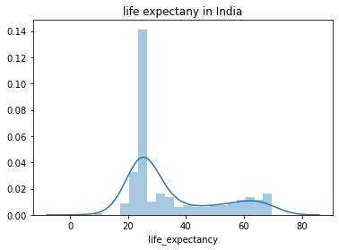

```python
x = gapminder_clean.loc['India']['life_expectancy']
sns.distplot(x, bins=20)
plt.title('life expectany in India');
```

```python
gapminder_clean.loc['India']['life_expectancy'].describe()
```

```
count    221.000000
mean      35.102534
std       15.428002
min        8.160000
25%       25.300000
50%       25.400000
75%       45.700000
max       69.700000
Name: life_expectancy, dtype: float64
```

```python
df_life_comparison.xs(2020, level='Year').life_expectancy.mean()
```

```
73.39130434782612
```

#### India

> life expectancy in India in **1800** was **25**, and over the 220 years, it was incressed to almost 70. largest declines coming in the **1870s & 1910s**, This because of **The Great Famine & Spanish Flu** both responsble for death over 7 million indian. As I mentioned earlier India's life expectancy has ncressed to 70, but it's still below the global average

> from the histogram and statistics above 25% of data is under 25.3 years of life expectancy! and 50% of data is also under 25.4 years of life expectancy. India have a messy distrubition of life expectancy especially the minmum value of life expectany was 8 years old ! ii cann't imagine that

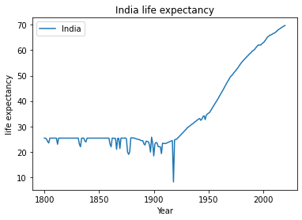

```python
custom_plot('India')
```

[figure not shown]

```python
plt.plot(gapminder_clean.loc['Bangladesh']['life_expectancy'], label='Bangladesh')
plt.plot(gapminder_clean.loc['Pakistan']['life_expectancy'], label='Pakistan')
plt.title('Bengladesh Vs Pakistan life expectancy')
plt.xlabel('Year')
plt.ylabel('life expectancy')
plt.legend()
plt.show();
```

#### Norway

> life expectancy in Norway was **37** in 1800s , and over the next 220 years it have increased ti **82 years** in 2020. there were several times where the rate deviated from its previous trajectory, and that was the result of **famine & influenza**, and again in the **1910s** because of **spanish flu**

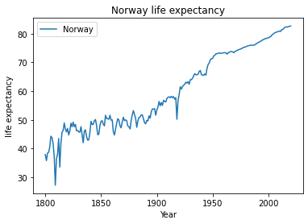

```python
custom_plot('Norway')
```

#### Sweden

> Life expectancy in Sweden was 32.16 in the year 1800, and over the course of the next 221 years, it is expected to have increased to 82.6 by 2020. Although life expectancy has generally increased throughout Sweden's history, there was a lot of fluctuation around the turn of the nineteenth century due to The Napoleonic Wars and First Cholera Epidemic, **and again in the 1910s due to the Spanish Flu Epidemic.**

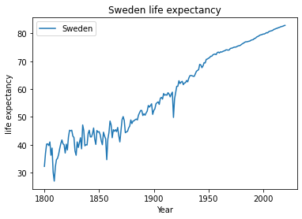

```python
custom_plot('Sweden')
```

#### Finland

> Life expectancy in Finland was 36.6 in the year 1800, and over the course of the next 221 years, it is expected to have increased by over double this, to 81.9 years by 2020. Although life expectancy has generally increased throughout Finland's history, it fluctuated greatly between 1800 and 1875, in the 1910s because of the Spanish Flu epidemic that swept across the world and the Finnish Civil War, and again during the Second World War in the 1930s and 40s.

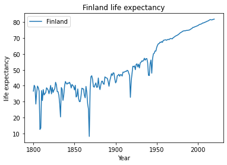

```python
custom_plot('Finland')
```

#### Spain

> Life expectancy in Spain was below thirty in the year 1800, it is expected to have increased to 83.5 by the year 2020. Although life expectancy has generally increased throughout Spain's history, there were several times where the rate deviated from its previous trajectory. The most notable changes were a result of the global influenza epidemic of the 1910s, (called the 'Spanish Flu' as it received more press coverage in neutral Spain, during the First World War) and the Spanish Civil War two decades later.

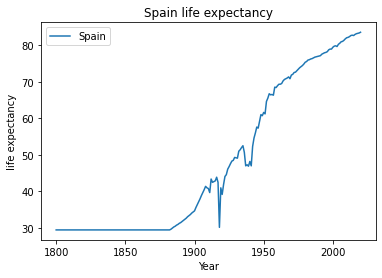

```python
custom_plot('Spain')
```

#### Germany

> we can se clearly that Germany had suffered havy losses during the **world war 2**, both in lives & income power. germany had a loss over **7 million** germans in war(9% of total population), and that explan why we have a great fluctuated in the 40s. But it has an great comeback, After the wat particulary after 50s germany became one of successful countries on the world, We can see that in **GDP/capita** plot & **GDP** plot

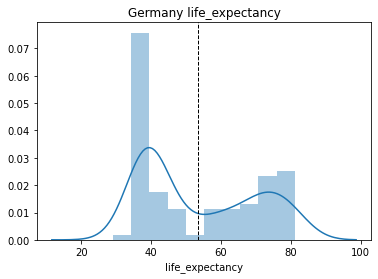

```python
x = gapminder_clean.loc['Germany']['life_expectancy']
sns.distplot(x, bins=10)
plt.axvline(x.mean(), color='k', linestyle='dashed', linewidth=1);
plt.title('Germany life_expectancy');
```

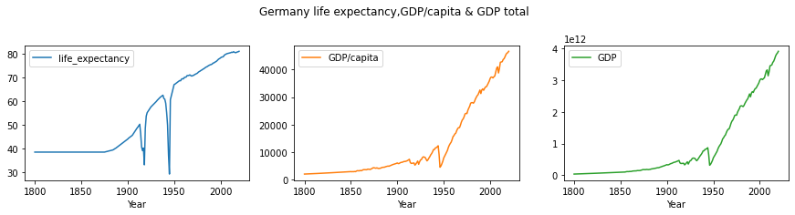

```python
gapminder_clean.loc['Germany'][['life_expectancy','GDP/capita','GDP']].plot(subplots=True, layout=(2, 3), figsize=(15, 6), sharex=False, title='Germany life expectancy,GDP/capita & GDP total');
```

#### ام الدنيا

> Between 1900 and 1950, Egypt’s life expectancy saw little change, hovering around 33 years, with the only decrease coming in the 1910s during the Spanish Flu epidemic and the Second World War. However, following the removal of the monarchy and establishment of the Egyptian republic in the 1952 Revolution, life expectancy saw a several decade rise, largely due to a significant expansion of the economy, health services, and other forms of social welfare; this increase then slowed between 1960 and 1975 as the economic growth in the country slowed, but it then increased to 68 years at the turn of the millennium. Since 2000, this growth has slowed, as a mixture of high population growth, high unemployment, and significant civil unrest have hit the country in the last two decades, although it has still reached 72 years in 2020, which is just one year below the global life expectancy.

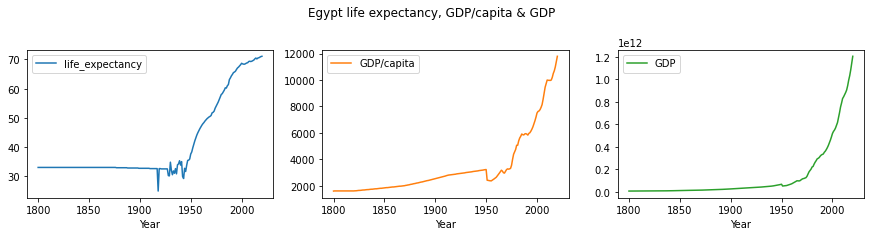

```python
gapminder_clean.loc['Egypt'][['life_expectancy','GDP/capita','GDP']].plot(subplots=True, layout=(2, 3), figsize=(15, 6), sharex=False, title = 'Egypt life expectancy, GDP/capita & GDP');
```

### power of economy

GDP is the total value of all goods and services produced in a country in a year. It is considered to be a very important indicator of the economic strength of a country and a positive change is an indicator of economic growth.

```python
df_GDP = gapminder_clean.sort_values(by=['GDP/capita','population'], ascending=False)
df_GDP[['GDP/capita','population']].xs(2020, level='Year')
```

| country | GDP/capita | population |
| --- | --- | --- |
| Qatar | 116000 | 2880000 |
| Luxembourg | 95100 | 626000 |
| Singapore | 90500 | 5850000 |
| Brunei | 75100 | 437000 |
| Ireland | 74100 | 4940000 |
| ... | ... | ... |
| Niger | 974 | 24200000 |
| Congo, Dem. Rep. | 845 | 89600000 |
| Central African Republic | 817 | 4830000 |
| Somalia | 633 | 15900000 |
| Burundi | 628 | 11900000 |

184 rows × 2 columns

```python
df_GDP[['GDP/capita','population']]
```

| country | Year | GDP/capita | population |
| --- | --- | --- | --- |
| United Arab Emirates | 1980 | 179000 | 1020000 |
| Qatar | 1973 | 178000 | 142000 |
| United Arab Emirates | 1981 | 177000 | 1100000 |
| Qatar | 1972 | 176000 | 131000 |
|  | 1976 | 174000 | 174000 |
| ... | ... | ... | ... |
| North Korea | 1819 | 245 | 4350000 |
|  | 1820 | 245 | 4350000 |
|  | 1821 | 245 | 4350000 |
|  | 1822 | 245 | 4350000 |
|  | 1823 | 245 | 4350000 |

40664 rows × 2 columns

```python
df_GDP.xs(2020, level='Year')['GDP/capita'].mean()
```

```
18496.179347826088
```

```python
# custom function to plot data
def custom_plot(x):
    gapminder_clean.loc[x][['GDP/capita','GDP','population']].plot(subplots=True, layout=(2, 3), figsize=(20, 7.5), sharex=False, title = x + ' Economy');
```

#### UAE & Qatar

> **UAE & Qatar** have the largest **GDP/capita** in Dataset, wher in **UAE** was **179000** in **1980**, and **Qatar** was **178000** in **1973**, and the resone of that was they have a low population when they have a large GDP total. but in 1990s the popualtion starts increasing so the GDP/capita Slide back a bit. but still they're over the global average

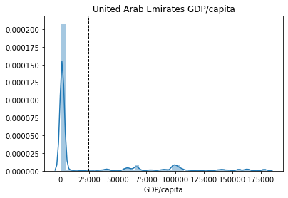

```python
x = gapminder_clean.loc['United Arab Emirates']['GDP/capita']
sns.distplot(x)
plt.axvline(x.mean(), color='k', linestyle='dashed', linewidth=1)
plt.title('United Arab Emirates GDP/capita');
```

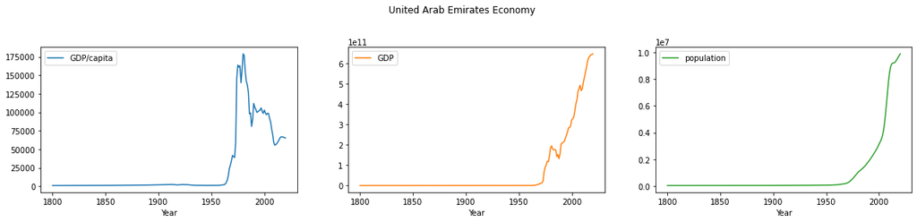

```python
custom_plot('United Arab Emirates')
```

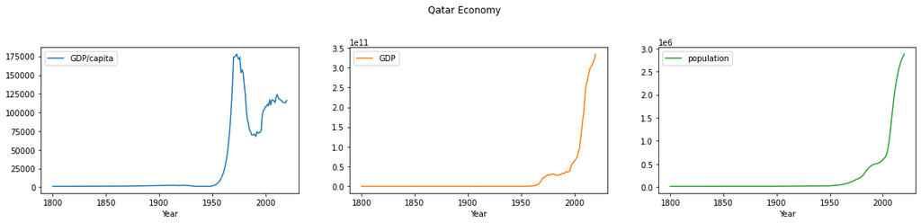

```python
custom_plot('Qatar')
```

#### Luxembourg

> The statistic shows gross domestic product (GDP) per capita in Luxembourg from 1800 to 2020*. In 2018, the GDP per capita in Luxembourg amounted to around 93700 U.S. dollars. By the way, Luxembourg is the country with the second largest GDP per capita worldwide as of 2020.

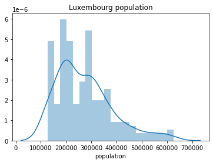

```python
x = gapminder_clean.loc['Luxembourg']['population']
sns.distplot(x, bins=20)
plt.title('Luxembourg population');
```

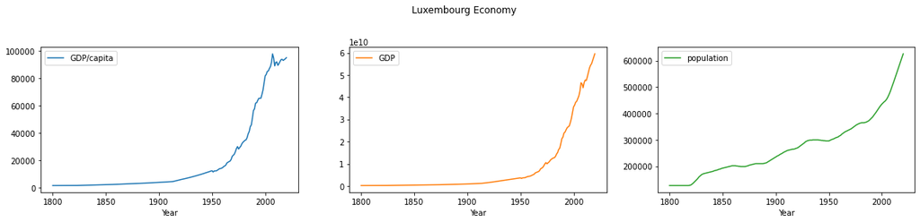

```python
custom_plot('Luxembourg')
```

[output not shown]

## Conclusions

### most powerfull countries in Economic

> GDP is the total value of all goods and services produced in a country in a year. It is considered to be a very important indicator of the economic strength of a country and a positive change is an indicator of economic growth.

> First i showed a table of largest **GDP/capita** in **2020** and **Qatar & luxembourg** was in the first of that table, then i showed a table of the **UAE & Qatar** was the most powerfull countries in **1970s & 1980s**

## limitations

- i think if the data of healthcare invesment is avalibale the result'll be more understandable especially on Life Expectancy Comparison section.

```python
from subprocess import call
call(['python', '-m', 'nbconvert', 'Investigate_a_Dataset.ipynb'])
```